# Lab 7

Griffin Shelor

10/19/2023

## Question 1.

A survey was conducted searching an area for wildlife mortalities. The data are contained in the file “ClusterData2.gpkg”. Looking at the data, the locations appear to be arranged in three clusters. Using the k means algorithm from the built in ‘stats’ package A) evaluate a range of clusters from 1:10 on your data set without scaling the coordinates. B) What appears to be an appropriate number of clusters for the data with respect to clustering on the coordinates? Why? C) plot the data symbolized by the new clusters that you identified with K-means.

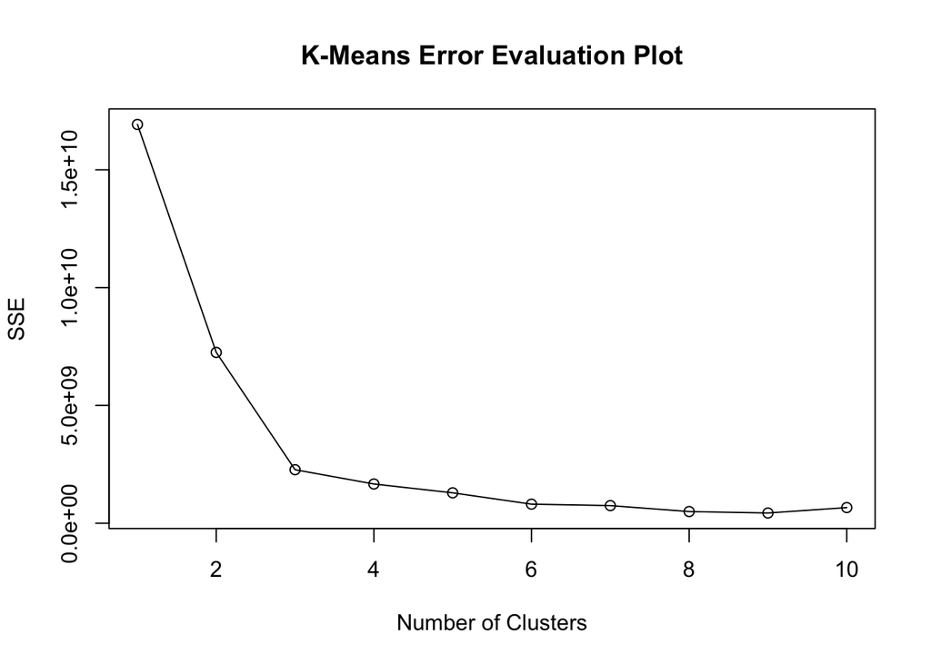

```r
## reading data
clusterdata <- read_sf("ClusterData2.gpkg")
set.seed(802)
nkm <- data.frame(number = numeric(10), sse = numeric(10)) # empty df to hold results
for(j in 1:10){ ## loop through each cluster number
  nkm$number[j] <- j ## cluster number
  nkm$sse[j] <- kmeans(st_coordinates(clusterdata),centers=j)$tot.withinss ## record error
}
plot(nkm$number, nkm$sse, xlab = 'Number of Clusters', ylab = 'SSE', main = 'K-Means Error Evaluation Plot')
lines(nkm$number, nkm$sse)
```

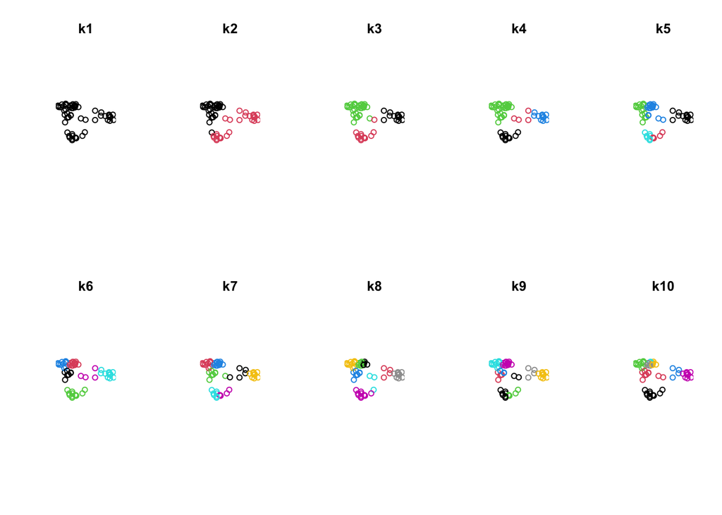

```r
## An appropriate number of clusters for the data appears to be 3. This is because there is a significant reduction in how much error is lost after we use 3 clusters. Most of the clusters greater than 3 have relatively similar levels of error.

## creating and plotting clusters
clusterk1 <- kmeans(st_coordinates(clusterdata),centers=1)
clusterk2 <- kmeans(st_coordinates(clusterdata),centers=2)
clusterk3 <- kmeans(st_coordinates(clusterdata),centers=3)
clusterk4 <- kmeans(st_coordinates(clusterdata),centers=4)
clusterk5 <- kmeans(st_coordinates(clusterdata),centers=5)
clusterk6 <- kmeans(st_coordinates(clusterdata),centers=6)
clusterk7 <- kmeans(st_coordinates(clusterdata),centers=7)
clusterk8 <- kmeans(st_coordinates(clusterdata),centers=8)
clusterk9 <- kmeans(st_coordinates(clusterdata),centers=9)
clusterk10 <- kmeans(st_coordinates(clusterdata),centers=10)

par(mfrow=c(2,5))
plot(st_geometry(clusterdata), col=factor(clusterk1$cluster), main = 'k1')
plot(st_geometry(clusterdata), col=factor(clusterk2$cluster), main = 'k2')
plot(st_geometry(clusterdata), col=factor(clusterk3$cluster), main = 'k3')
plot(st_geometry(clusterdata), col=factor(clusterk4$cluster), main = 'k4')
plot(st_geometry(clusterdata), col=factor(clusterk5$cluster), main = 'k5')
plot(st_geometry(clusterdata), col=factor(clusterk6$cluster), main = 'k6')
plot(st_geometry(clusterdata), col=factor(clusterk7$cluster), main = 'k7')
plot(st_geometry(clusterdata), col=factor(clusterk8$cluster), main = 'k8')
plot(st_geometry(clusterdata), col=factor(clusterk9$cluster), main = 'k9')
plot(st_geometry(clusterdata), col=factor(clusterk10$cluster), main = 'k10')
```

• Answer - There appears to be a sharp reduction in the error improvement at k=3

## Question 2

1. Add the “sex” column to your clustering. Does this increase the number of potential clusters identified? B) Evaluate clusters on the coordinates and sex columns. C) How many clusters look reasonable now? D) Plot your result.

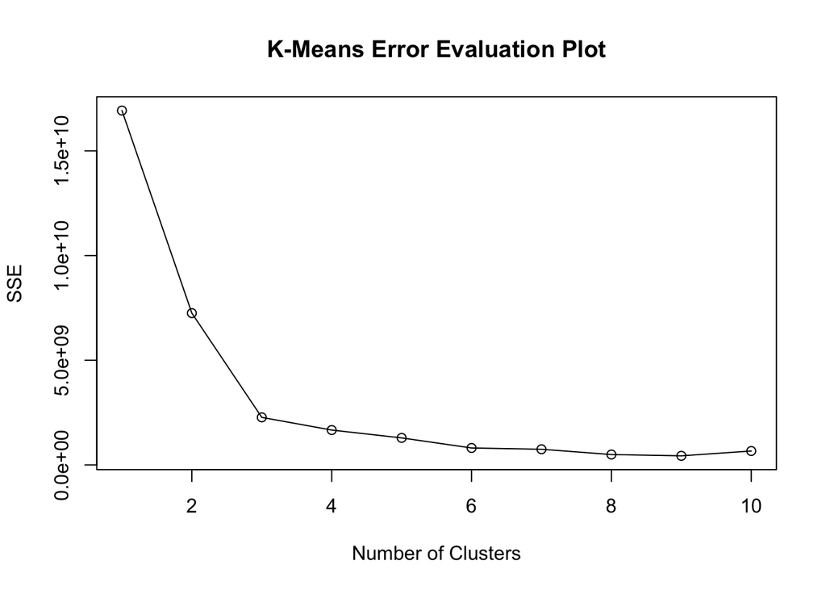

```r
set.seed(802)
## Evaluating Clusters
nkm_sex <- data.frame(number = numeric(10), sse = numeric(10)) # empty df to hold results
for(j in 1:10){ ## loop through each cluster number
  nkm_sex$number[j] <- j ## cluster number
  nkm_sex$sse[j] <- kmeans(cbind(st_coordinates(clusterdata),as.factor(clusterdata$sex)),centers=j)$tot.withinss ## record error
}
plot(nkm_sex$number, nkm_sex$sse, xlab = 'Number of Clusters', ylab = 'SSE', main = 'K-Means Error Evaluation Plot')
lines(nkm_sex$number, nkm_sex$sse)
```

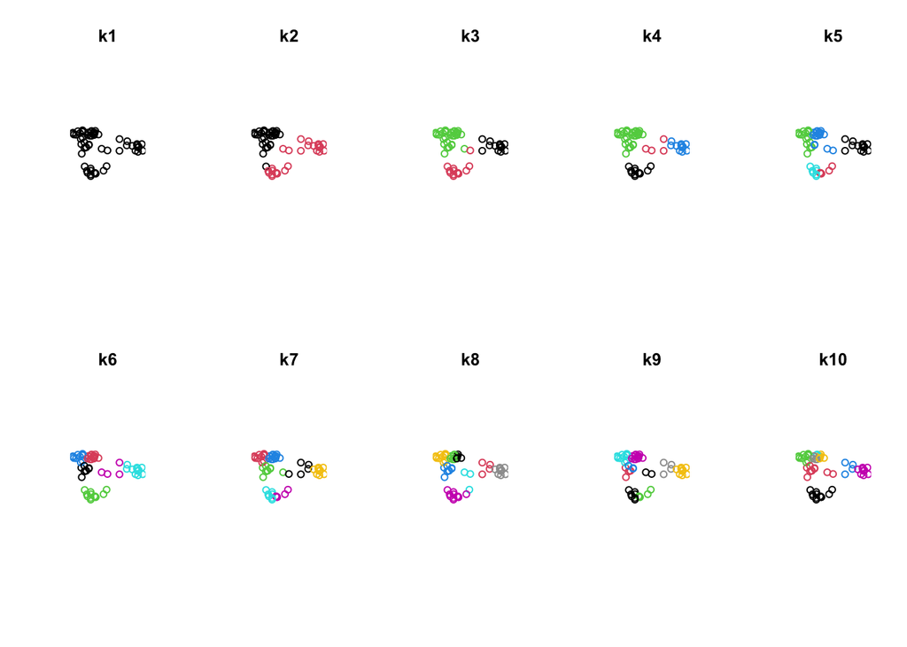

```r
## Based on this plot, the appropriate number of clusters is still 3. The error improvement is significantly reduced after we use clusters greater than 3.

## creating and plotting clusters
clusterk1_sex <- kmeans(cbind(st_coordinates(clusterdata), as.factor(clusterdata$sex)),centers=1)
clusterk2_sex <- kmeans(cbind(st_coordinates(clusterdata), as.factor(clusterdata$sex)),centers=2)
clusterk3_sex <- kmeans(cbind(st_coordinates(clusterdata), as.factor(clusterdata$sex)),centers=3)
clusterk4_sex <- kmeans(cbind(st_coordinates(clusterdata), as.factor(clusterdata$sex)),centers=4)
clusterk5_sex <- kmeans(cbind(st_coordinates(clusterdata), as.factor(clusterdata$sex)),centers=5)
clusterk6_sex <- kmeans(cbind(st_coordinates(clusterdata), as.factor(clusterdata$sex)),centers=6)
clusterk7_sex <- kmeans(cbind(st_coordinates(clusterdata), as.factor(clusterdata$sex)),centers=7)
clusterk8_sex <- kmeans(cbind(st_coordinates(clusterdata), as.factor(clusterdata$sex)),centers=8)
clusterk9_sex <- kmeans(cbind(st_coordinates(clusterdata), as.factor(clusterdata$sex)),centers=9)
clusterk10_sex <- kmeans(cbind(st_coordinates(clusterdata), as.factor(clusterdata$sex)),centers=10)

par(mfrow=c(2,5))
plot(st_geometry(clusterdata), col=factor(clusterk1_sex$cluster), main = 'k1')
plot(st_geometry(clusterdata), col=factor(clusterk2_sex$cluster), main = 'k2')
plot(st_geometry(clusterdata), col=factor(clusterk3_sex$cluster), main = 'k3')
plot(st_geometry(clusterdata), col=factor(clusterk4_sex$cluster), main = 'k4')
plot(st_geometry(clusterdata), col=factor(clusterk5_sex$cluster), main = 'k5')
plot(st_geometry(clusterdata), col=factor(clusterk6_sex$cluster), main = 'k6')
plot(st_geometry(clusterdata), col=factor(clusterk7_sex$cluster), main = 'k7')
plot(st_geometry(clusterdata), col=factor(clusterk8_sex$cluster), main = 'k8')
plot(st_geometry(clusterdata), col=factor(clusterk9_sex$cluster), main = 'k9')
plot(st_geometry(clusterdata), col=factor(clusterk10_sex$cluster), main = 'k10')
```